output: html_document: default pdf_document: default — Whitewines Exploring by Erin ========================================================

```
##        X        fixed.acidity    volatile.acidity  citric.acid
##  Min.   :   1   Min.   : 3.800   Min.   :0.0800   Min.   :0.0000
##  1st Qu.:1225   1st Qu.: 6.300   1st Qu.:0.2100   1st Qu.:0.2700
##  Median :2450   Median : 6.800   Median :0.2600   Median :0.3200
##  Mean   :2450   Mean   : 6.855   Mean   :0.2782   Mean   :0.3342
##  3rd Qu.:3674   3rd Qu.: 7.300   3rd Qu.:0.3200   3rd Qu.:0.3900
##  Max.   :4898   Max.   :14.200   Max.   :1.1000   Max.   :1.6600
##  residual.sugar     chlorides       free.sulfur.dioxide
##  Min.   : 0.600   Min.   :0.00900   Min.   :  2.00
##  1st Qu.: 1.700   1st Qu.:0.03600   1st Qu.: 23.00
##  Median : 5.200   Median :0.04300   Median : 34.00
##  Mean   : 6.391   Mean   :0.04577   Mean   : 35.31
##  3rd Qu.: 9.900   3rd Qu.:0.05000   3rd Qu.: 46.00
##  Max.   :65.800   Max.   :0.34600   Max.   :289.00
##  total.sulfur.dioxide    density             pH          sulphates
##  Min.   :  9.0        Min.   :0.9871   Min.   :2.720   Min.   :0.2200
##  1st Qu.:108.0        1st Qu.:0.9917   1st Qu.:3.090   1st Qu.:0.4100
##  Median :134.0        Median :0.9937   Median :3.180   Median :0.4700
##  Mean   :138.4        Mean   :0.9940   Mean   :3.188   Mean   :0.4898
##  3rd Qu.:167.0        3rd Qu.:0.9961   3rd Qu.:3.280   3rd Qu.:0.5500
##  Max.   :440.0        Max.   :1.0390   Max.   :3.820   Max.   :1.0800
##     alcohol         quality
##  Min.   : 8.00   Min.   :3.000
##  1st Qu.: 9.50   1st Qu.:5.000
##  Median :10.40   Median :6.000
##  Mean   :10.51   Mean   :5.878
##  3rd Qu.:11.40   3rd Qu.:6.000
##  Max.   :14.20   Max.   :9.000
```

# Univariate Plots Section

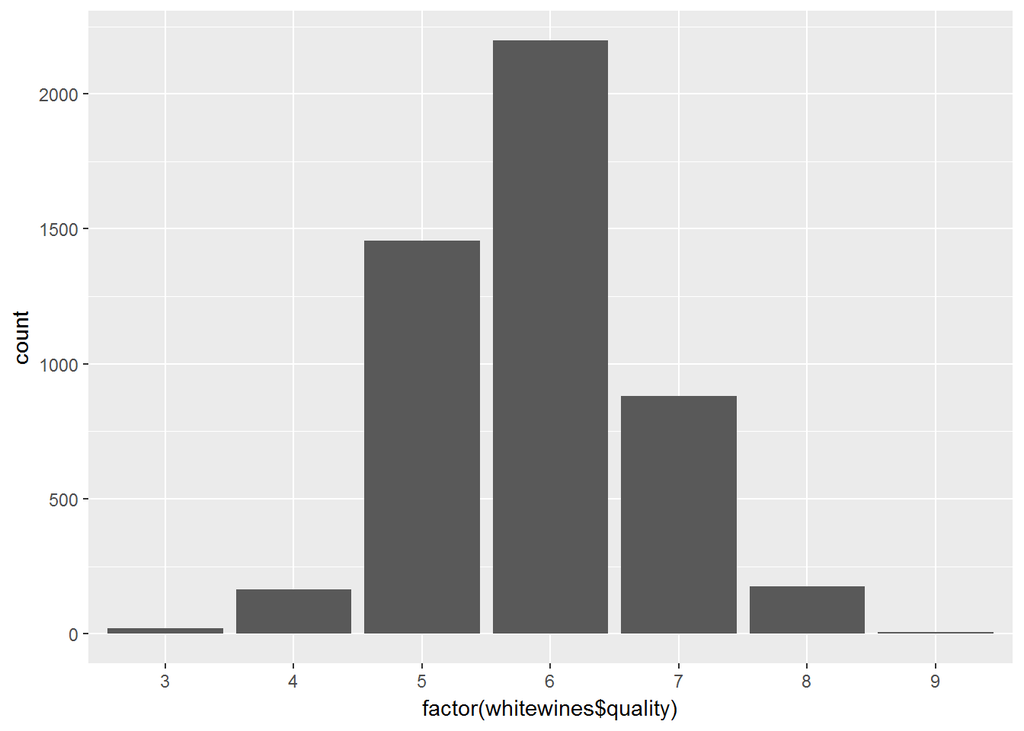

From the bar chat, we can see most whitewine’s quality is between 5~7,below 5 or above 7 is rare.

```
## 'data.frame':    4898 obs. of  13 variables:
##  $ X                   : int  1 2 3 4 5 6 7 8 9 10 ...
##  $ fixed.acidity       : num  7 6.3 8.1 7.2 7.2 8.1 6.2 7 6.3 8.1 ...
##  $ volatile.acidity    : num  0.27 0.3 0.28 0.23 0.23 0.28 0.32 0.27 0.3 0.22 ...
##  $ citric.acid         : num  0.36 0.34 0.4 0.32 0.32 0.4 0.16 0.36 0.34 0.43 ...
##  $ residual.sugar      : num  20.7 1.6 6.9 8.5 8.5 6.9 7 20.7 1.6 1.5 ...
##  $ chlorides           : num  0.045 0.049 0.05 0.058 0.058 0.05 0.045 0.045 0.049 0.044 ...
##  $ free.sulfur.dioxide : num  45 14 30 47 47 30 30 45 14 28 ...
##  $ total.sulfur.dioxide: num  170 132 97 186 186 97 136 170 132 129 ...
##  $ density             : num  1.001 0.994 0.995 0.996 0.996 ...
##  $ pH                  : num  3 3.3 3.26 3.19 3.19 3.26 3.18 3 3.3 3.22 ...
##  $ sulphates           : num  0.45 0.49 0.44 0.4 0.4 0.44 0.47 0.45 0.49 0.45 ...
##  $ alcohol             : num  8.8 9.5 10.1 9.9 9.9 10.1 9.6 8.8 9.5 11 ...
##  $ quality             : int  6 6 6 6 6 6 6 6 6 6 ...
```

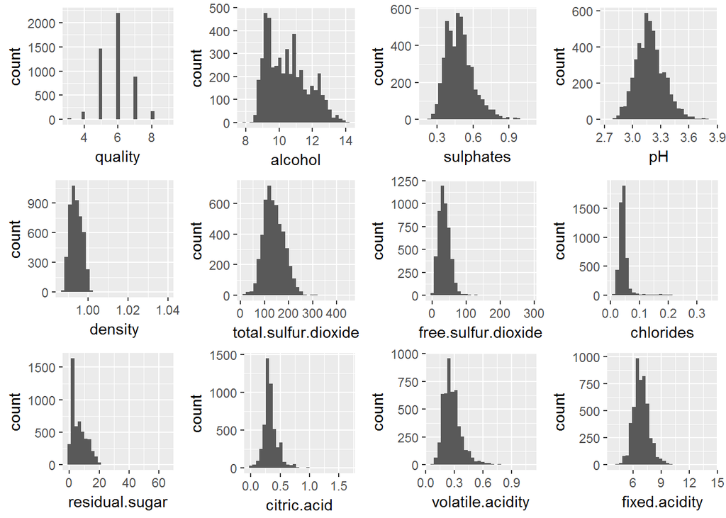

```
##  fixed.acidity    volatile.acidity  citric.acid     residual.sugar
##  Min.   : 3.800   Min.   :0.0800   Min.   :0.0000   Min.   : 0.600
##  1st Qu.: 6.300   1st Qu.:0.2100   1st Qu.:0.2700   1st Qu.: 1.700
##  Median : 6.800   Median :0.2600   Median :0.3200   Median : 5.200
##  Mean   : 6.855   Mean   :0.2782   Mean   :0.3342   Mean   : 6.391
##  3rd Qu.: 7.300   3rd Qu.:0.3200   3rd Qu.:0.3900   3rd Qu.: 9.900
##  Max.   :14.200   Max.   :1.1000   Max.   :1.6600   Max.   :65.800
##    chlorides       free.sulfur.dioxide total.sulfur.dioxide
##  Min.   :0.00900   Min.   :  2.00      Min.   :  9.0
##  1st Qu.:0.03600   1st Qu.: 23.00      1st Qu.:108.0
##  Median :0.04300   Median : 34.00      Median :134.0
##  Mean   :0.04577   Mean   : 35.31      Mean   :138.4
##  3rd Qu.:0.05000   3rd Qu.: 46.00      3rd Qu.:167.0
##  Max.   :0.34600   Max.   :289.00      Max.   :440.0
##     density             pH          sulphates         alcohol
##  Min.   :0.9871   Min.   :2.720   Min.   :0.2200   Min.   : 8.00
##  1st Qu.:0.9917   1st Qu.:3.090   1st Qu.:0.4100   1st Qu.: 9.50
##  Median :0.9937   Median :3.180   Median :0.4700   Median :10.40
##  Mean   :0.9940   Mean   :3.188   Mean   :0.4898   Mean   :10.51
##  3rd Qu.:0.9961   3rd Qu.:3.280   3rd Qu.:0.5500   3rd Qu.:11.40
##  Max.   :1.0390   Max.   :3.820   Max.   :1.0800   Max.   :14.20
##     quality
##  Min.   :3.000
##  1st Qu.:5.000
##  Median :6.000
##  Mean   :5.878
##  3rd Qu.:6.000
##  Max.   :9.000
```

```
##    Min. 1st Qu.  Median    Mean 3rd Qu.    Max.
##    8.00    9.50   10.40   10.51   11.40   14.20
```

[figure not shown]

Alcohol distribution is right skewed Poisson distribution.

```
##    Min. 1st Qu.  Median    Mean 3rd Qu.    Max.
##  0.9871  0.9917  0.9937  0.9940  0.9961  1.0390
```

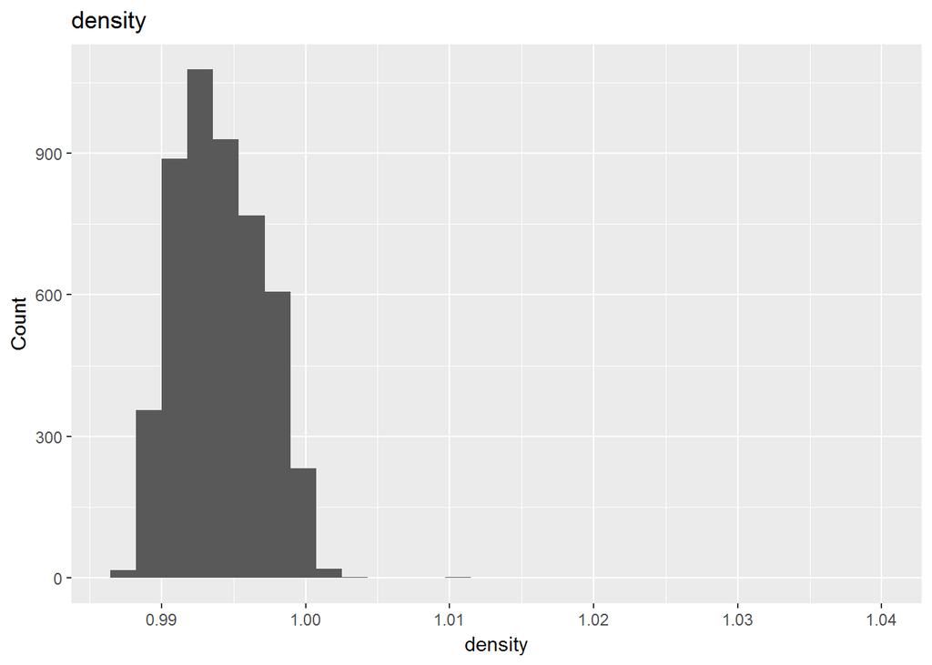

Density distribution is more like a normal distribution.

```
##    Min. 1st Qu.  Median    Mean 3rd Qu.    Max.
## 0.00900 0.03600 0.04300 0.04577 0.05000 0.34600
```

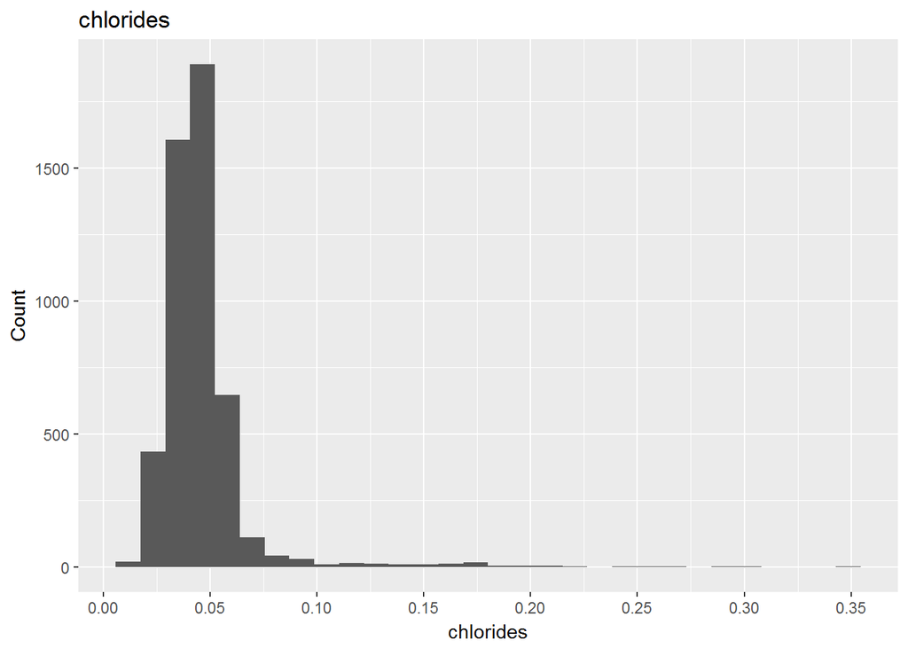

```
##    Min. 1st Qu.  Median    Mean 3rd Qu.    Max.
##  0.0800  0.2100  0.2600  0.2782  0.3200  1.1000
```

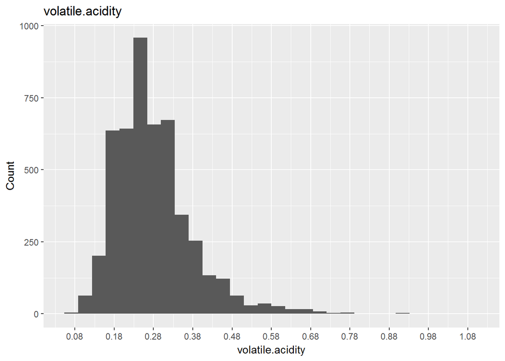

Volatile.acidity distribution is right skewed Poisson distribution.

```
##    Min. 1st Qu.  Median    Mean 3rd Qu.    Max.
##     9.0   108.0   134.0   138.4   167.0   440.0
```

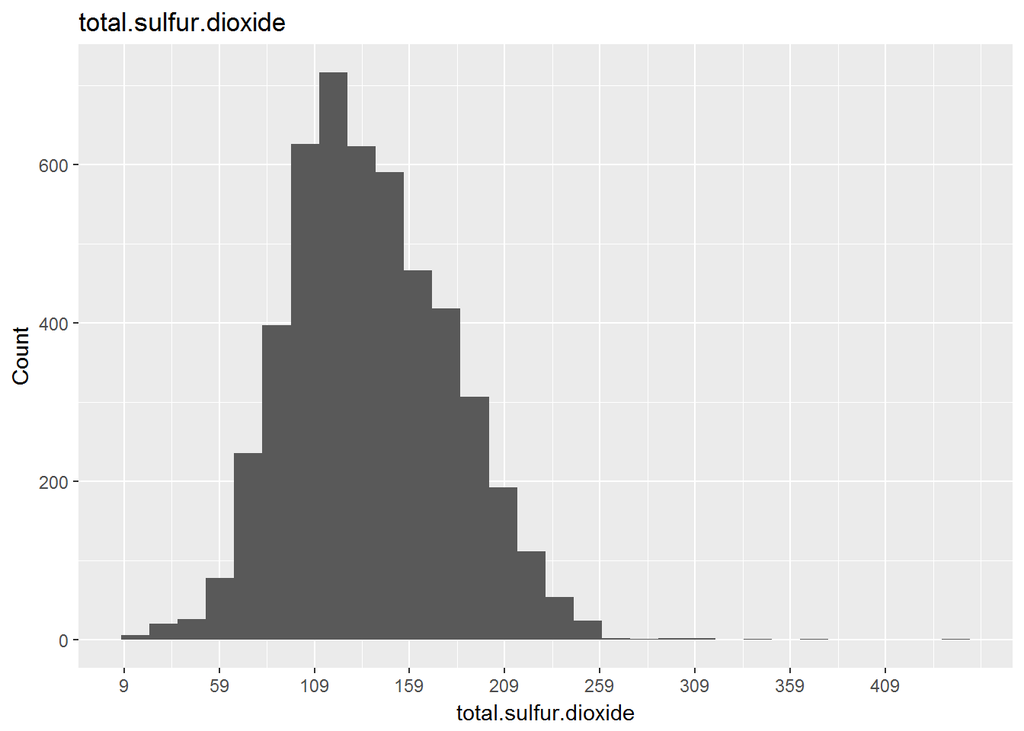

Total.sulfur.dioxide distribution is more like a normal distribution.

# Univariate Analysis

### What is the structure of your dataset?

The whitewines dataset has 4898 observations of 13 variables,which the X variable is not a real variable, it’s the data record number.

### What is/are the main feature(s) of interest in your dataset?

‘quality’ is the dependent variable,and the rest 11 variables is the independent variable.The dependent variable ‘quality’ and independent variables ‘alcohol’,‘density’,‘chlorides’,‘volatile.acidity’ and ‘total.sulfur.dioxide’ are the main features of interest.

### What other features in the dataset do you think will help support your investigation into your feature(s) of interest?

From ggpairs we can see there’s no significant feature that have strong correlation with ‘quality’, we need the independent variables together to explore the relationship.

### Did you create any new variables from existing variables in the dataset?

```
##    Min. 1st Qu.  Median    Mean 3rd Qu.    Max.
##   0.600   1.700   5.200   6.391   9.900  65.800
```

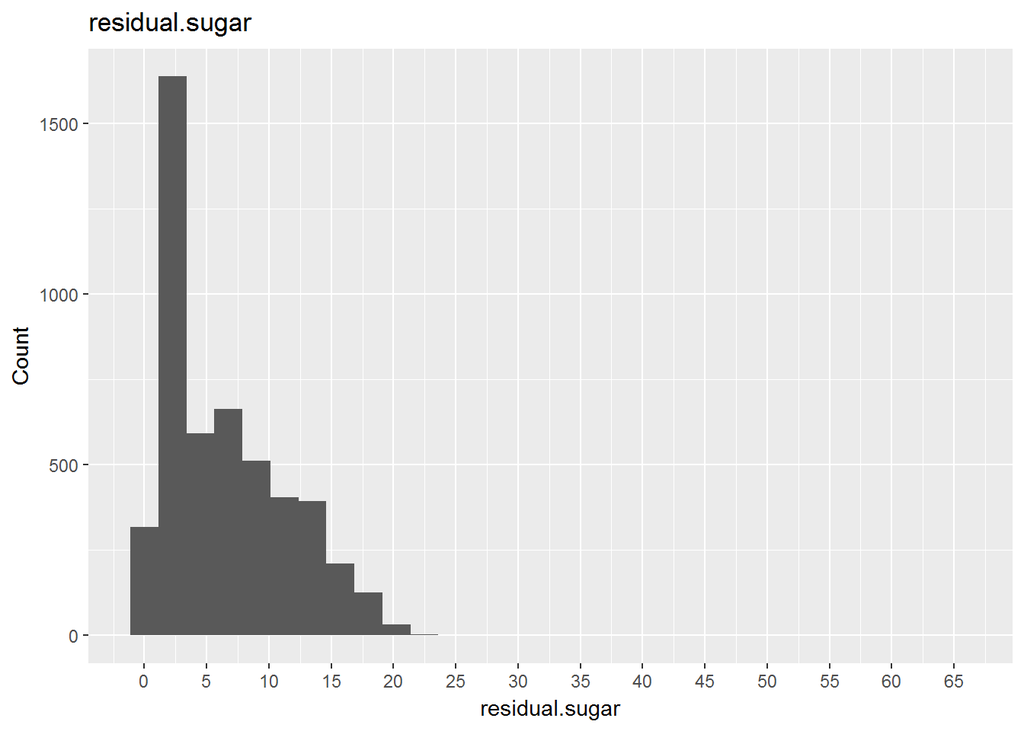

Residual.sugar distribution is unusual. The left side looks like a normal distribution, while the right side is more like a possion distribution.

```
##    Min. 1st Qu.  Median    Mean 3rd Qu.    Max.
##   0.600   1.700   5.200   6.391   9.900  65.800
```

[figure not shown]

```
##    Min. 1st Qu.  Median    Mean 3rd Qu.    Max.
##  0.0000  0.2700  0.3200  0.3342  0.3900  1.6600
```

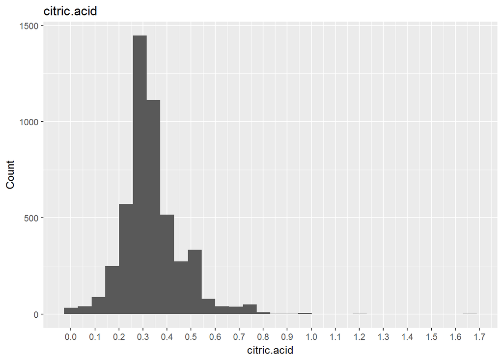

Citric.acid distribution is more like a normal distribution.But there is a peak left 0.5(citric.acid) and left 0.75(citric.acid).

```
##    Min. 1st Qu.  Median    Mean 3rd Qu.    Max.
##  0.2200  0.4100  0.4700  0.4898  0.5500  1.0800
```

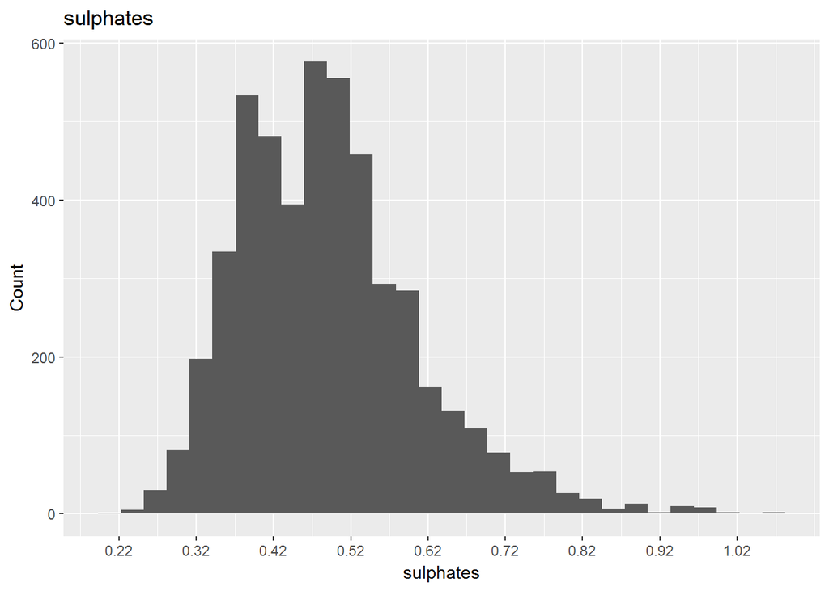

Sulphates distribution is more like a right skewed possion distribution.

# Bivariate Plots Section

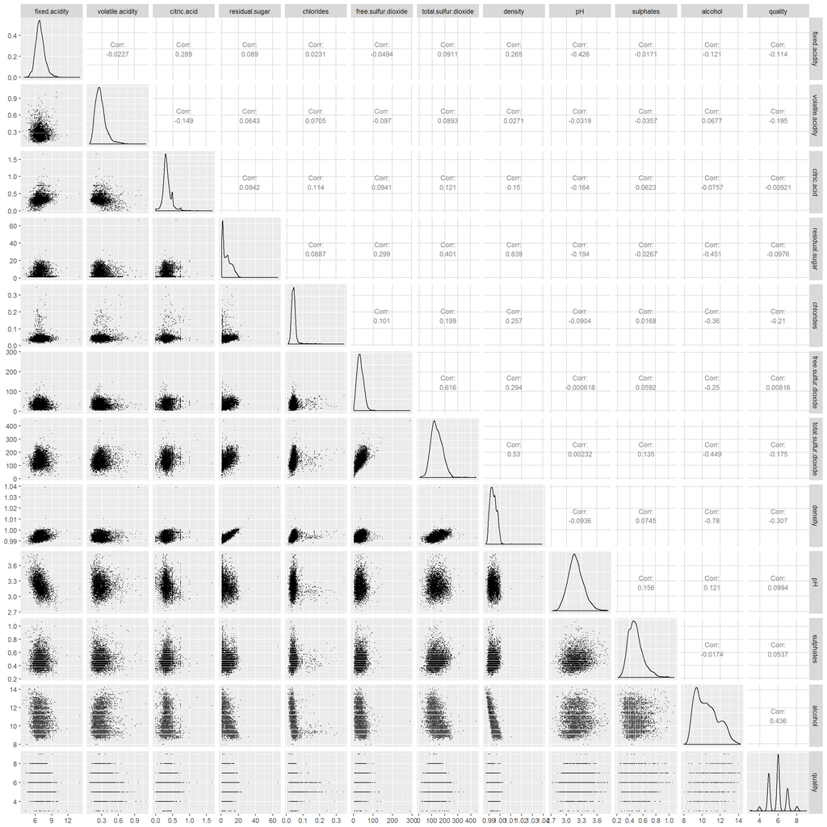

From ggpairs we can see the overall relationship between two variables, and then we can check the variables we care about in details.

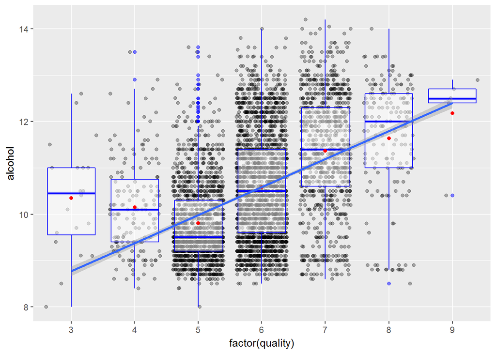

It seems when the alcohol goes up, the quality is increasing(when quality >=5).

```
## [1] 0.4355747
```

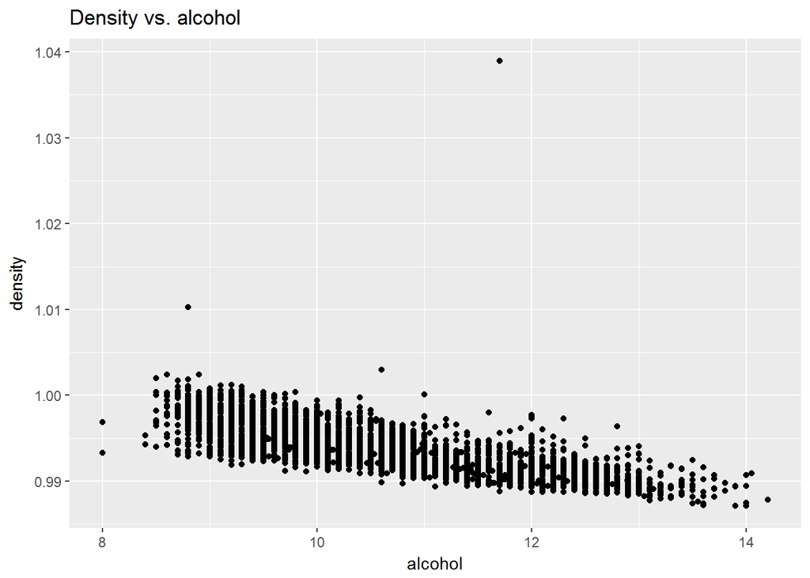

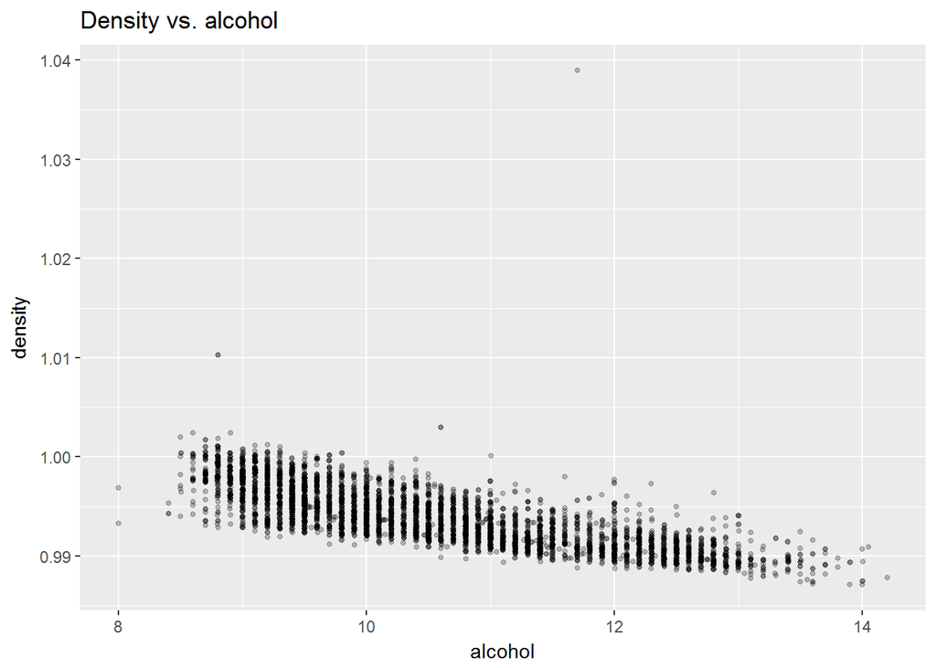

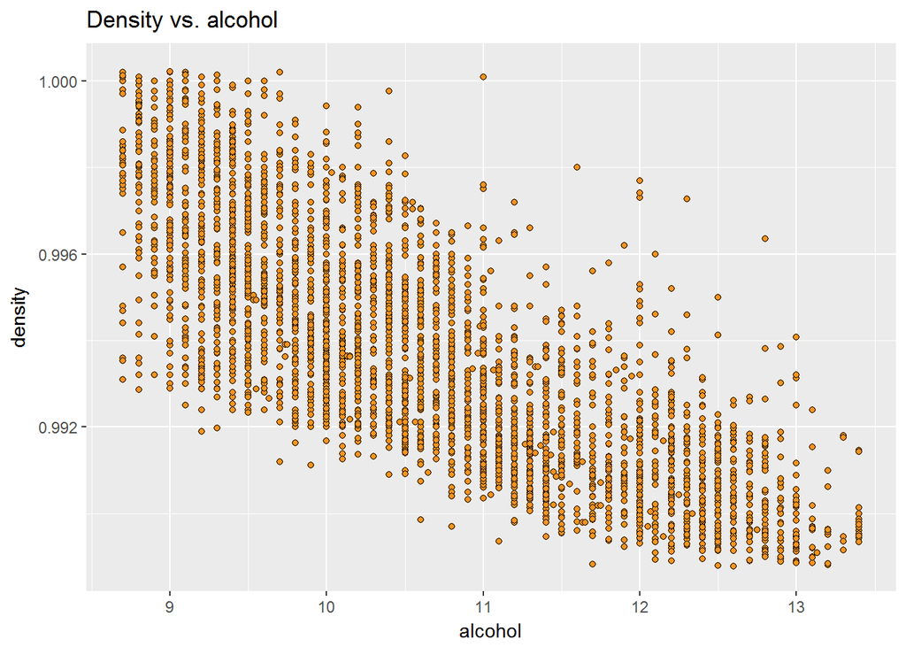

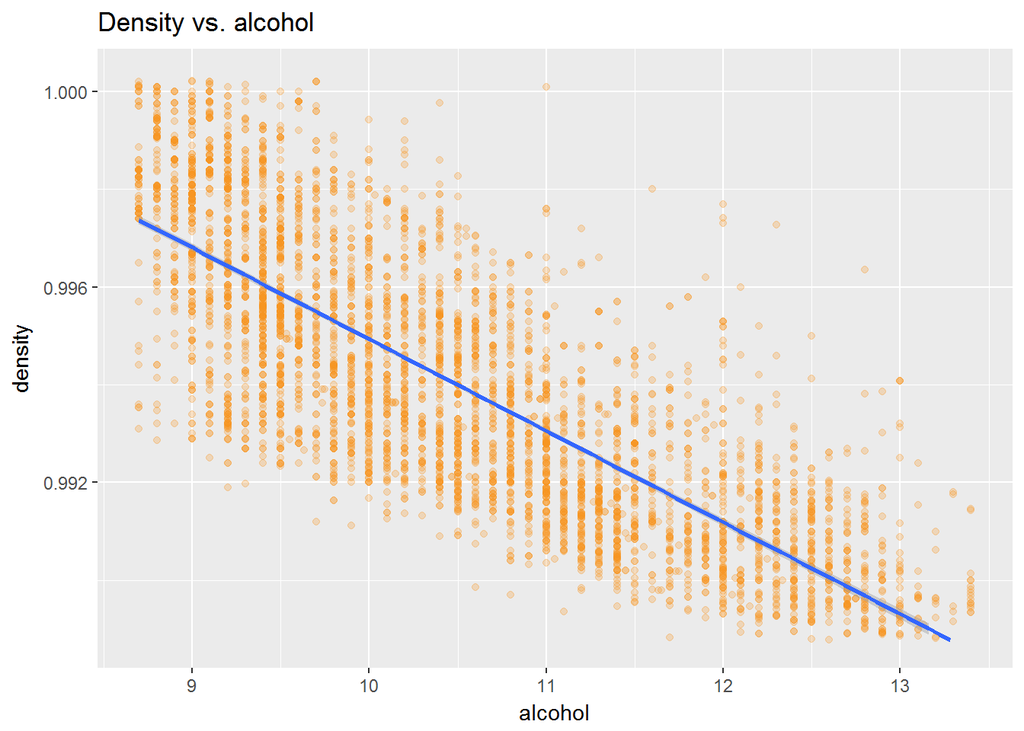

```
## [1] -0.7801376
```

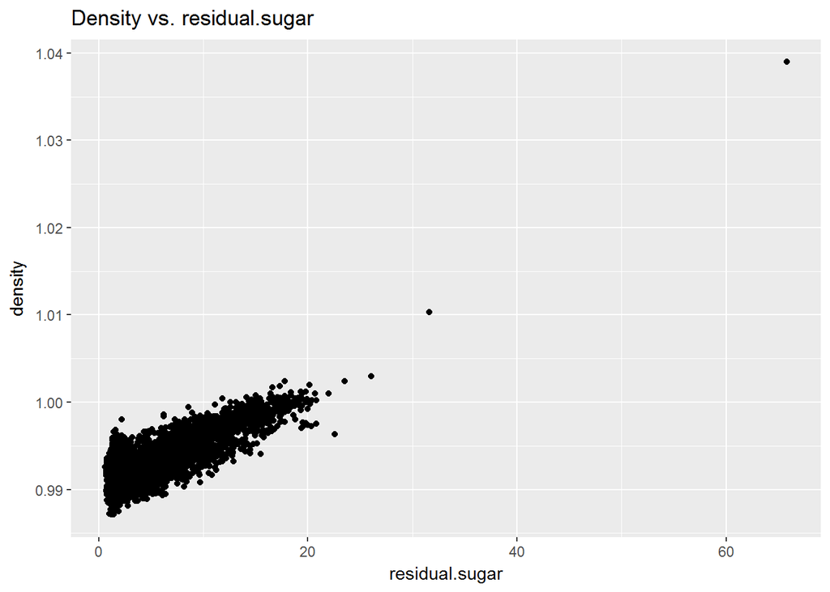

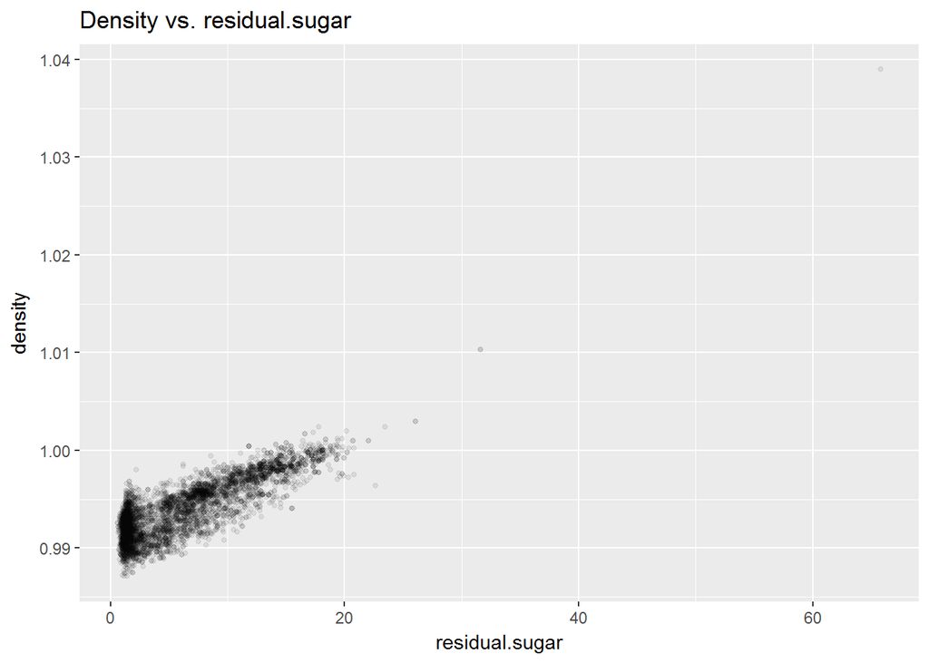

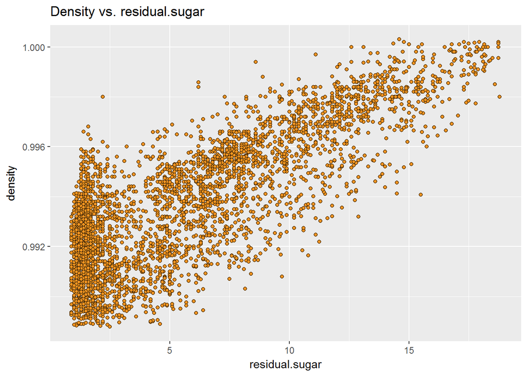

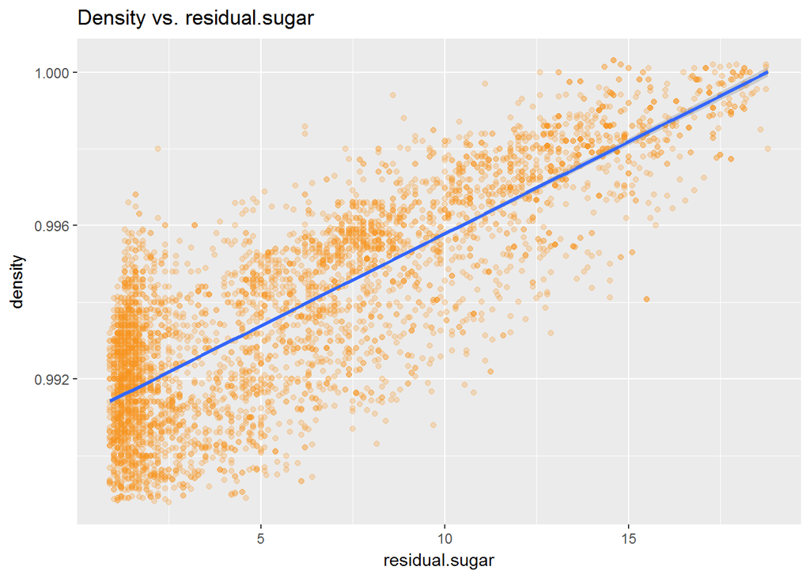

```
## [1] 0.8389665
```

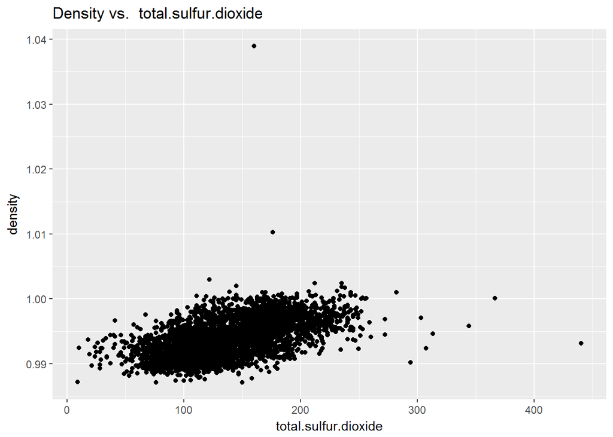

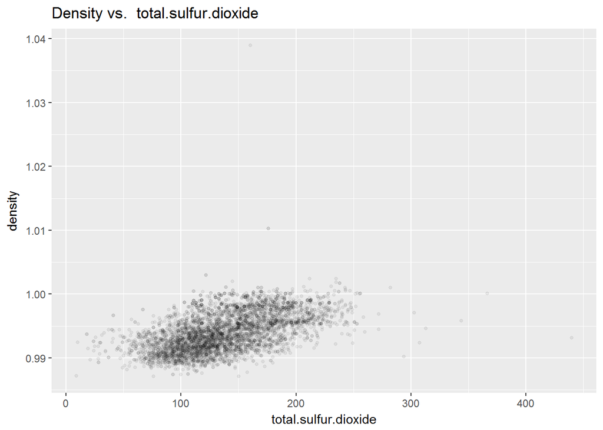

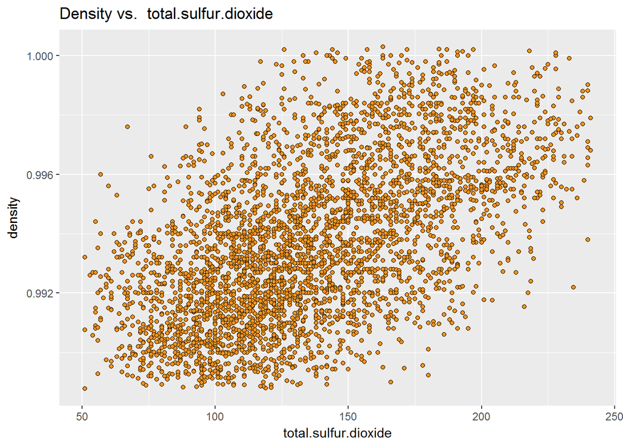

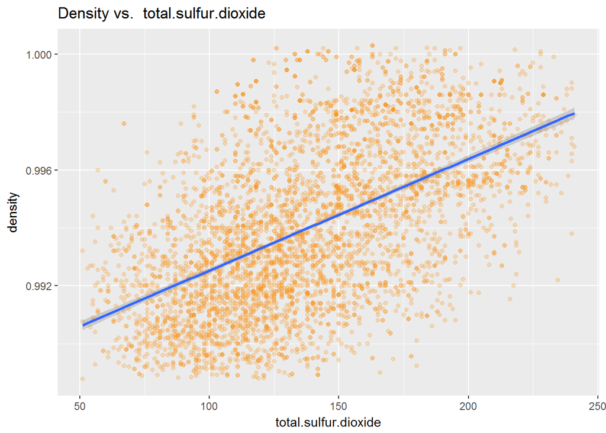

```
## [1] 0.5298813
```

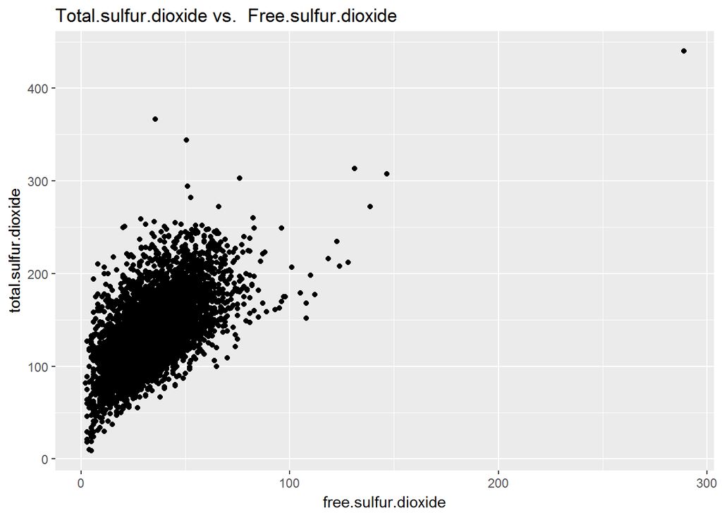

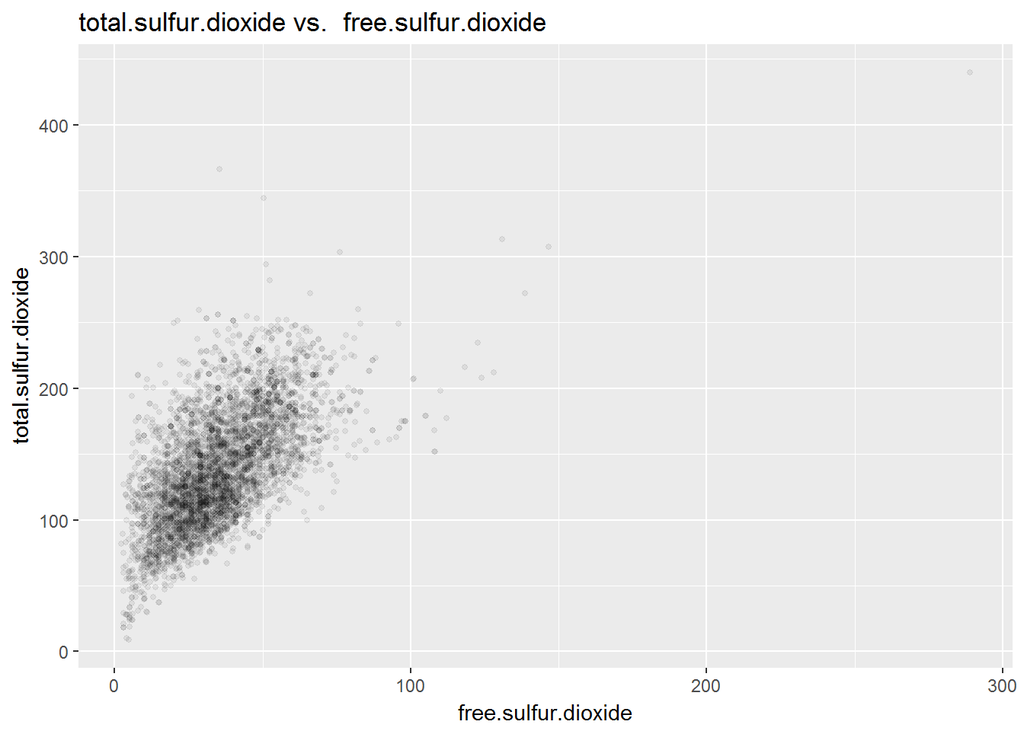

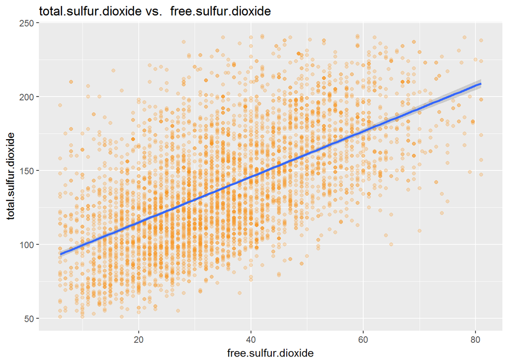

```
## [1] 0.615501
```

Total.sulfur.dioxide is highly related with free.sulfur.dioxide.So when we create a linear model,we should use one parameter of them.

# Bivariate Analysis

### Talk about some of the relationships you observed in this part of the investigation. How did the feature(s) of interest vary with other features in the dataset?

From the above chart,we can see the density rises with residual.sugar increases,while density decreases with alcohol increases.And they are highly related. ### Did you observe any interesting relationships between the other features (not the main feature(s) of interest)?

Density is highly related with residual.sugar and alcohol.When we keep the residual.sugar constant, the density increase with the alcohol decrease. Total.sulfur.dioxide is highly related with free.sulfur.dioxide.So when we create a linear model,we should use just one parameter of them.

### What was the strongest relationship you found?

Density vs. residual.sugar, the correlation is almost 0.84.

# Multivariate Plots Section

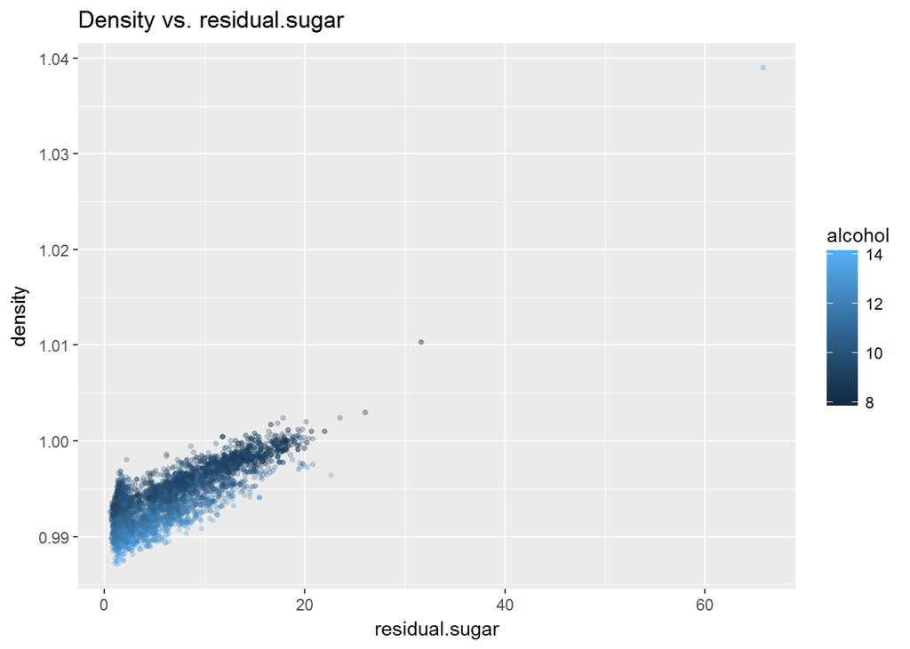

Density is highly related with residual.sugar and alcohol.When we keep the residual.sugar constant, the density increase with the alcohol decrease.

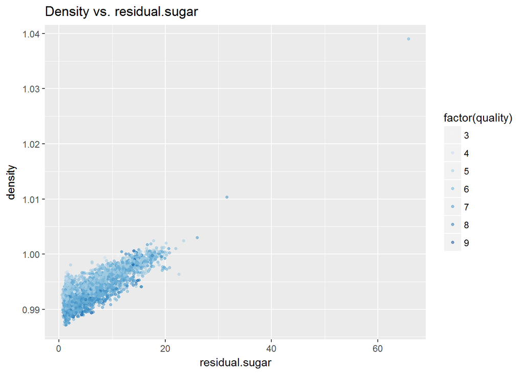

Keep the density constant,with residual.sugar increase,the quality increases.

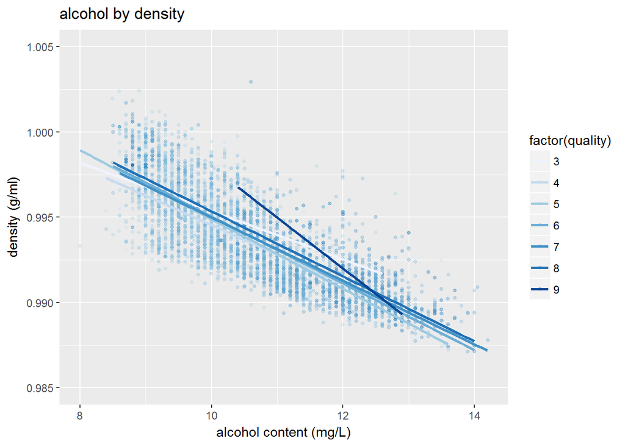

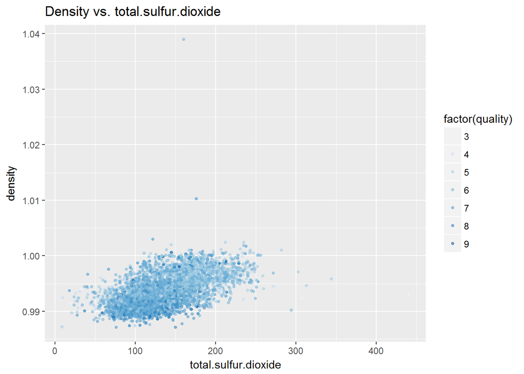

```
##
## Calls:
## m1: lm(formula = quality ~ alcohol, data = whitewines)
## m2: lm(formula = quality ~ alcohol + residual.sugar, data = whitewines)
## m3: lm(formula = quality ~ alcohol + residual.sugar + chlorides,
##     data = whitewines)
## m4: lm(formula = quality ~ alcohol + residual.sugar + chlorides +
##     volatile.acidity, data = whitewines)
## m5: lm(formula = quality ~ alcohol + residual.sugar + chlorides +
##     volatile.acidity + total.sulfur.dioxide, data = whitewines)
## m6: lm(formula = quality ~ alcohol + residual.sugar + chlorides +
##     volatile.acidity + total.sulfur.dioxide + sulphates, data = whitewines)
## m7: lm(formula = quality ~ alcohol + residual.sugar + chlorides +
##     volatile.acidity + total.sulfur.dioxide + sulphates + pH,
##     data = whitewines)
##
## =====================================================================================================
##                            m1         m2         m3         m4         m5         m6         m7
## -----------------------------------------------------------------------------------------------------
##   (Intercept)            2.582***   2.021***   2.276***   2.464***   2.334***   2.153***   1.251***
##                         (0.098)    (0.117)    (0.135)    (0.131)    (0.148)    (0.153)    (0.274)
##   alcohol                0.313***   0.354***   0.339***   0.368***   0.374***   0.373***   0.371***
##                         (0.009)    (0.010)    (0.011)    (0.011)    (0.011)    (0.011)    (0.011)
##   residual.sugar                    0.022***   0.021***   0.026***   0.025***   0.026***   0.028***
##                                    (0.002)    (0.003)    (0.002)    (0.003)    (0.003)    (0.003)
##   chlorides                                   -2.062***  -0.907     -0.966     -0.971     -0.819
##                                               (0.556)    (0.540)    (0.541)    (0.540)    (0.541)
##   volatile.acidity                                       -2.086***  -2.108***  -2.084***  -2.074***
##                                                          (0.110)    (0.110)    (0.110)    (0.110)
##   total.sulfur.dioxide                                               0.001      0.000      0.000
##                                                                     (0.000)    (0.000)    (0.000)
##   sulphates                                                                     0.437***   0.383***
##                                                                                (0.097)    (0.097)
##   pH                                                                                       0.296***
##                                                                                           (0.075)
## -----------------------------------------------------------------------------------------------------
##   R-squared                  0.2        0.2        0.2        0.3        0.3        0.3        0.3
##   adj. R-squared             0.2        0.2        0.2        0.3        0.3        0.3        0.3
##   sigma                      0.8        0.8        0.8        0.8        0.8        0.8        0.8
##   F                       1146.4      619.4      418.6      427.5      342.9      290.3      251.8
##   p                          0.0        0.0        0.0        0.0        0.0        0.0        0.0
##   Log-likelihood         -5839.4    -5802.2    -5795.3    -5620.7    -5618.9    -5608.6    -5600.8
##   Deviance                3112.3     3065.3     3056.7     2846.4     2844.2     2832.4     2823.4
##   AIC                    11684.8    11612.3    11600.6    11253.3    11251.7    11233.3    11219.6
##   BIC                    11704.3    11638.3    11633.1    11292.3    11297.2    11285.2    11278.1
##   N                       4898       4898       4898       4898       4898       4898       4898
## =====================================================================================================
```